# Predicting the Impact of Air Quality on Mortality Rates in England

May 29, 2018

## Abstract

- New estimates from the World Health Organization indicate that air pollution levels remain alarmingly high throughout the world.
- An estimated nine out of ten individuals breathe polluted air on a daily basis causing an estimated seven million premature deaths annually from ambient and household air pollution.
- The objective of our project is to use daily averages of air quality data and temperature to accurately predict mortality rates throughout regions of England.

## Background

- Kaggle
  - Copernicus Atmosphere Monitoring Service (pollution)
  - UK Office for National Statistics (Mortality Rates)
  - n = 18,403 (6,570 samples with partially complete data)
  - Seven features (Region, Date, Temperature, 4 Major Pollutants)

## Data Dictionary

- Id: Unique identification number for each row
- region: One of the nine official regions of England
- date: 1/2/2007 - 12/31/2012
- O3: Ozone, daily average (\(\mu\)g/\(m^3\))
- PM10: Particulate matter, 10\(\mu\)m or less in diameter, daily average (\(\mu\)g/\(m^3\))
- PM25: Particulate matter, 2.5\(\mu\)m or less in diameter, daily average (\(\mu\)g/\(m^3\))
- NO2: Nitrogen dioxide, daily average (\(\mu\)g/\(m^3\))
- T2M: Temperature (Kelvin) 2m above ground, daily average
- mortality_rate: Deaths per 100,000 people

## Preliminary Feature Engineering (1/2)

- Pollutants and Temperature
  - Attempt to extract additional value from dataset by partitioning continuous values into three categories (Low, Moderate, High).
    - Low (Below 25th Percentile)
    - Moderate (25th - 75th Percentile)
    - High (Above 75th Percentile)
- Date
  - Partitioned into Winter, Spring, Summer, Fall

## Preliminary Feature Engineering (2/2)

- Air Quality Index (AQI)
  - Recommended by UK's Committee on Medical Effects of Air Pollutants
  - Numeric value from 1 to 10 (1 Highest Quality Air, 10 Lowest Quality Air)
  - Based on concentration of pollutants

## Table 1 - Region

| Region | Mortality Rate 1.30 (.30) |
| --- | --- |
| North East | 1.47 (.32) |
| North West | 1.43 (.26) |
| Yorkshire and The Humber | 1.38 (.26) |
| East Midlands | 1.28 (.27) |
| West Midlands | 1.28 (.26) |
| East of England | 1.27 (.24) |
| London | 0.88 (.18) |
| South East | 1.26 (.24) |
| South West | 1.40 (.28) |

## Table 1 - Ozone Level

| Ozone Level | Mortality Rate 1.30 (.30) |
| --- | --- |
| High (n=4598) | 1.31 (.25) |
| Moderate (n=9197) | 1.27 (.29) |
| Low (n=4599) | 1.35 (.26) |

## Table 1 - Nitrogen Dioxide Level

| NO2 Level | Mortality Rate 1.30 (.30) |
| --- | --- |
| High (n=2958) | 1.24 (.36) |
| Moderate (n=5915) | 1.27 (.27) |
| Low (n=2960) | 1.27 (.26) |

## Table 1 - Particulate Matter 10 Level

| PM10 Level | Mortality Rate 1.30 (.30) |
| --- | --- |
| High (n=4598) | 1.27 (.31) |
| Moderate (n=9197) | 1.29 (.30) |
| Low (n=4599) | 1.36 (.30) |

## Table 1 - Particulate Matter 2.5 Level

| PM25 Level | Mortality Rate 1.30 (.30) |
| --- | --- |
| High (n=3782) | 1.26 (.31) |
| Moderate (n=7562) | 1.27 (.30) |
| Low (n=3783) | 1.34 (.29) |

## Table 1 - Temperature (Kelvin) Level

| Temp Level | Mortality Rate 1.30 (.30) |
| --- | --- |
| High (n=4601) | 1.12 (.22) |
| Moderate (n=9201) | 1.29 (.27) |
| Low (n=4601) | 1.50 (.32) |

## Table 1 - Season

| Season | Mortality Rate 1.30 (.30) | AQI 2.00 (.50) |
| --- | --- | --- |
| Winter (n=4579) | 1.54 (.33) | 1.90 (0.49) |
| Spring (n=4674) | 1.27 (.25) | 2.34 (0.51) |
| Summer (n=4600) | 1.12 (.22) | 1.96 (.33) |
| Fall (n=4550) | 1.28 (.26) | 1.78 (.47) |

## Table 1 - AQI

| AQI | Mortality Rate 1.30 (.30) |
| --- | --- |
| Index 1 (n=2272) | 1.38 (.38) |
| Index 2 (n=13970) | 1.29 (.30) |
| Index 3 (n=2101) | 1.30 (.26) |
| Index 4 (n=49) | 1.22 (.24) |
| Index 5 (n=11) | 1.18 (.21) |

## Exploratory Data Analysis

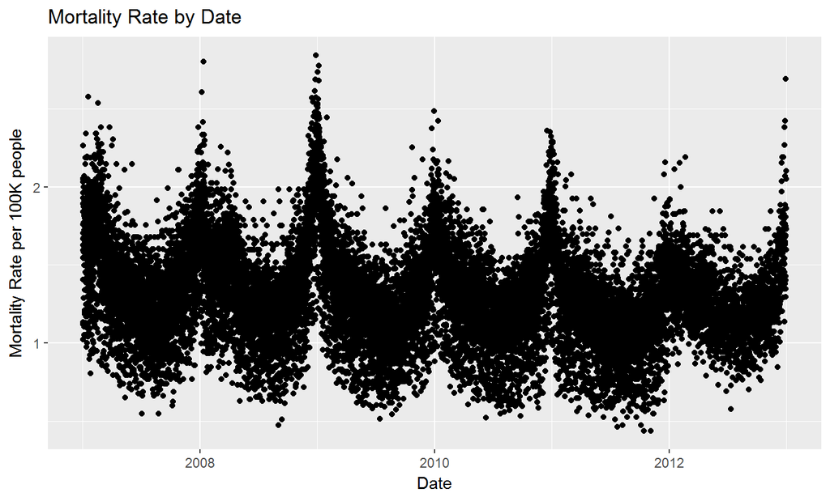

## Exploratory Data Analysis

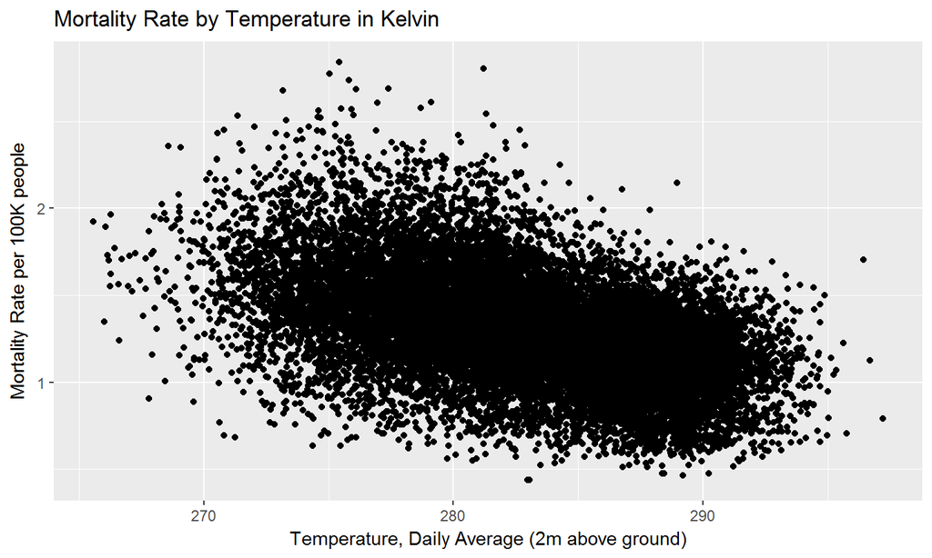

## Exploratory Data Analysis

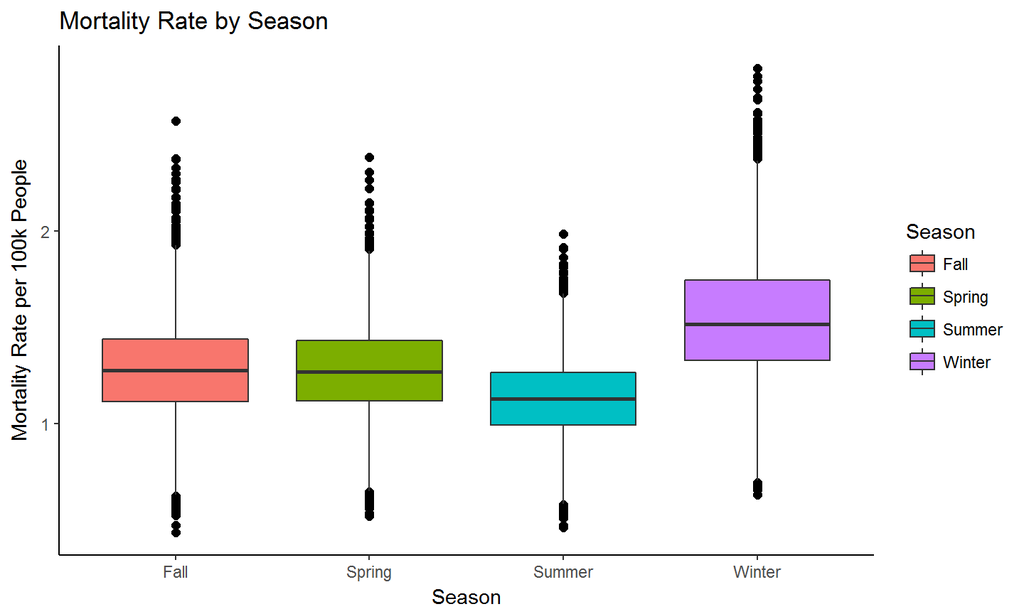

## Exploratory Data Analysis

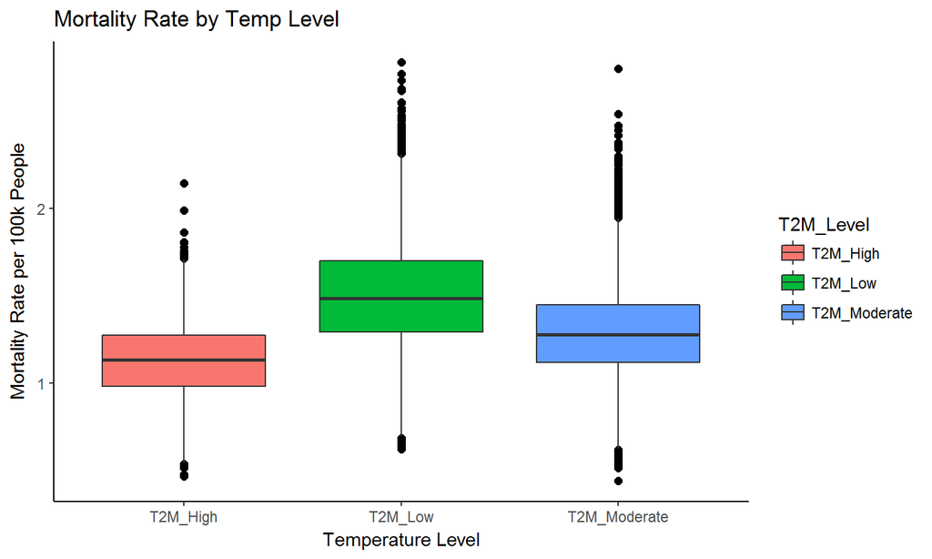

## Exploratory Data Analysis

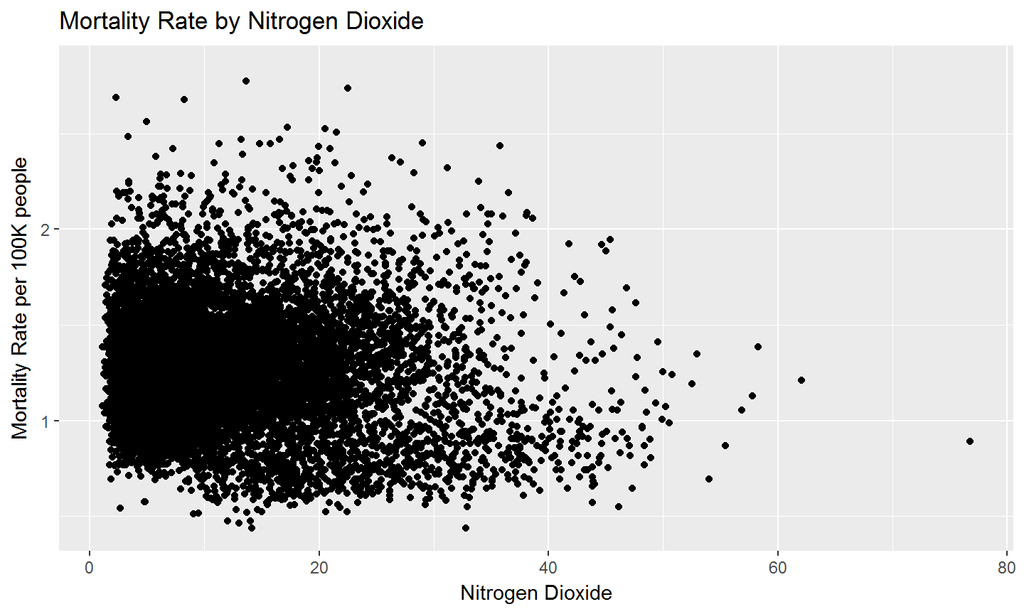

## Exploratory Data Analysis

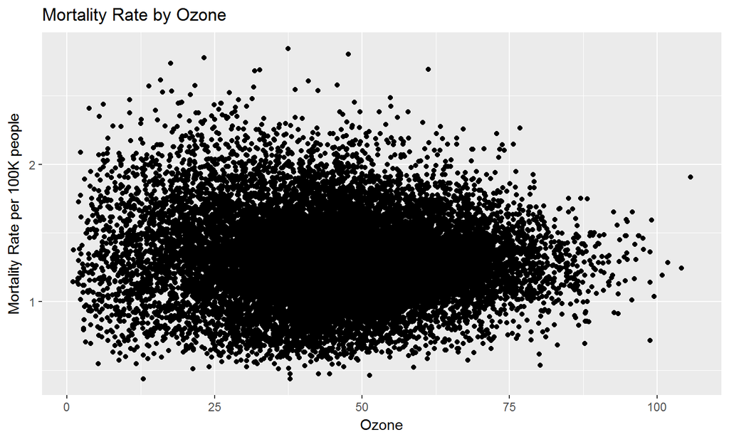

## Exploratory Data Analysis

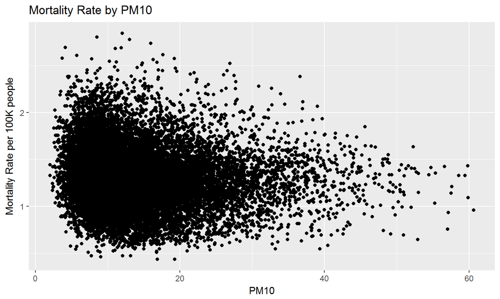

## Exploratory Data Analysis

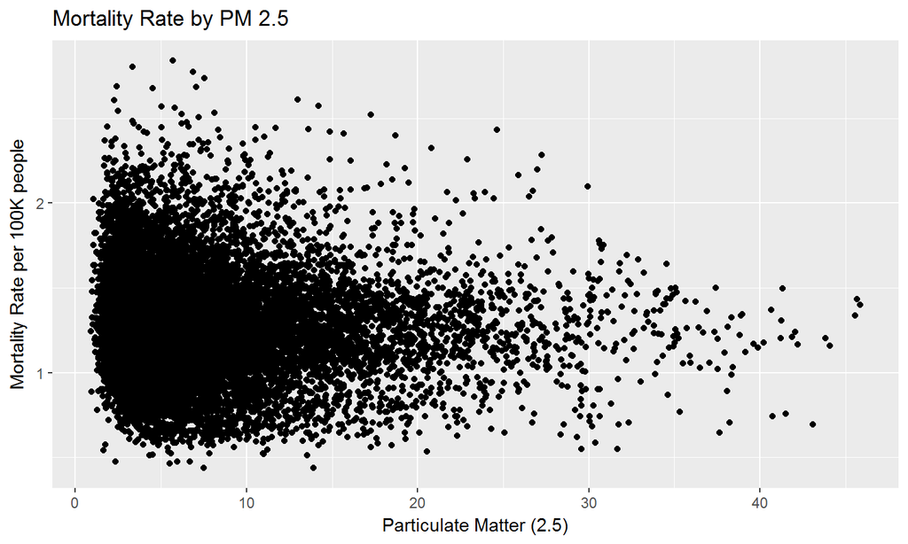

## Exploratory Data Analysis

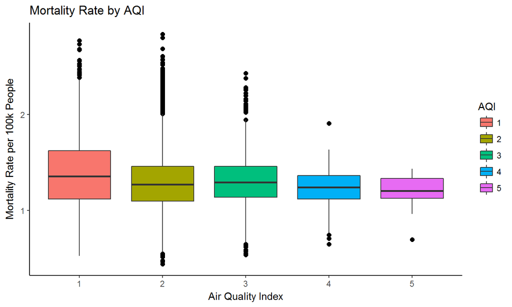

## Exploratory Data Analysis - Region

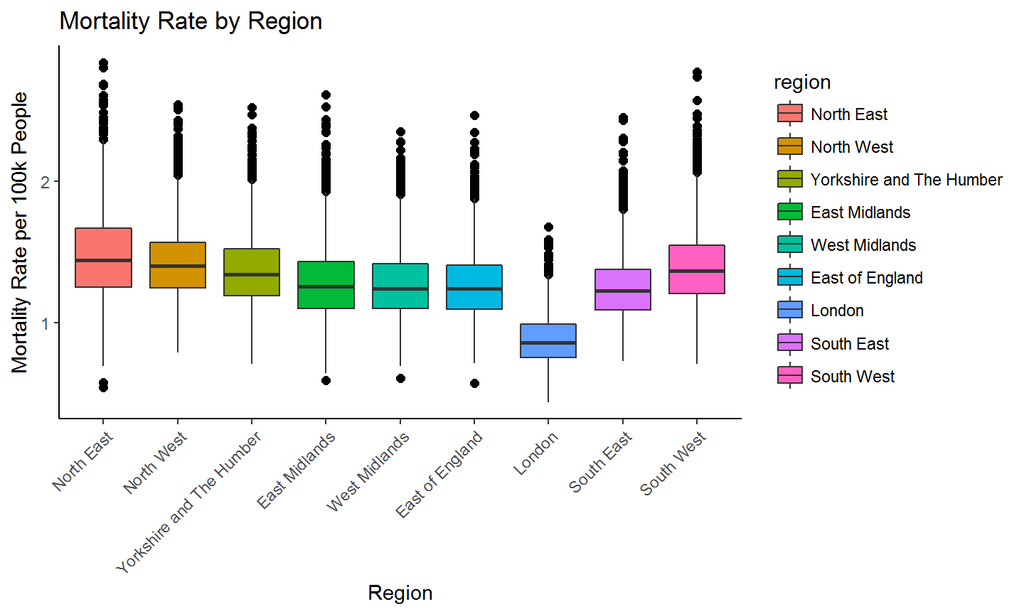

## Modelling Progression

- Simple Linear Regression
- Multiple Linear Regression
- Random Forests
- Artificial Neural Networks

## Regression

| Model | Train/Test Data Split | Data PreProcessing | Model Accuracy |
| --- | --- | --- | --- |
| LM1 | 70-30 | NA Records Omitted | 0.5959228 |
| LM2 | 70-30 | kNN Imputation | 0.5731310 |
| LM3 | 80-20 | NA Records Omitted | 0.5966913 |
| LM4 | 80-20 | kNN Imputation | 0.5619385 |

## Regression Analysis (1/2)

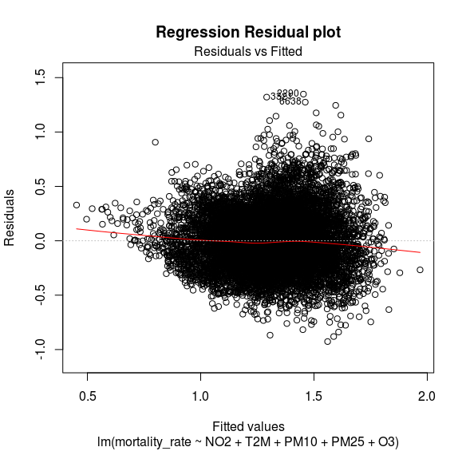

## Regression Analysis (2/2)

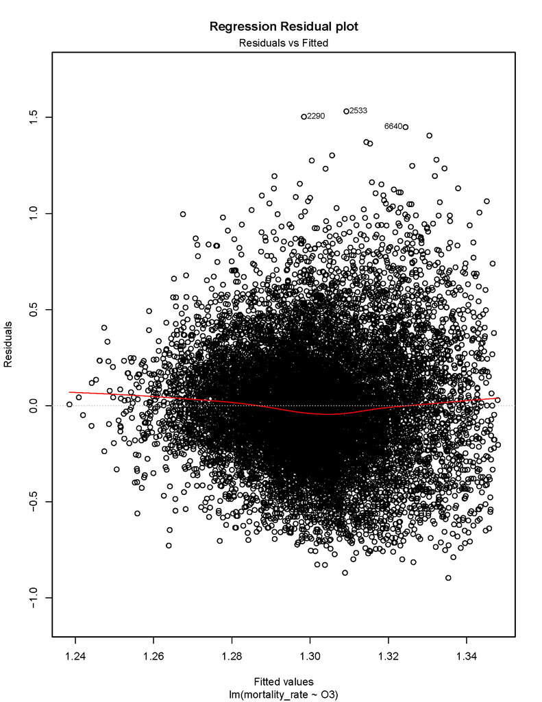

## Random Forests

| Model | Train/Test Data Split | Data PreProcessing | Model Accuracy |
| --- | --- | --- | --- |
| RF1 | 70-30 | NA Records Omitted | 0.7704970 |
| RF2 | 70-30 | kNN Imputation | 0.7572889 |
| RF3 | 80-20 | NA Records Omitted | 0.7639935 |
| RF4 | 80-20 | kNN Imputation | 0.7485153 |

## Variable Importance

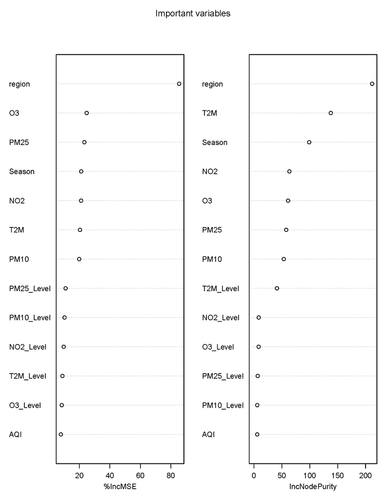

## Artificial Neural Networks

| Model | Train/Test Data Split | Data PreProcessing | Model Accuracy |
| --- | --- | --- | --- |
| NN1 | 70-30 | NA Records Omitted | 0.7673420 |
| NN2 | 70-30 | kNN Imputation | 0.7539171 |
| NN3 | 80-20 | NA Records Omitted | 0.7759289 |
| NN4 | 80-20 | kNN Imputation | 0.7455035 |

## Modelling Performance

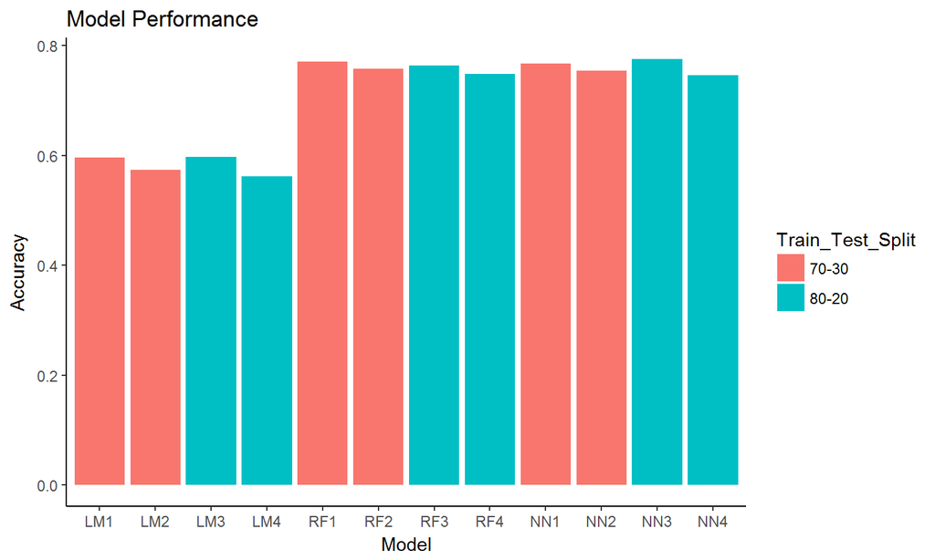